# Phase 2 — Which Differences Are Real? Hypothesis Tests & Effect Sizes

Zohair Khan

2026-07-07

## Purpose

Phase 1 flagged candidate drivers by eye. This phase asks two harder questions for each one:

1. **Is the difference real** (unlikely under chance), after correcting for the fact that we’re running a whole battery of tests?
2. **Is it big enough to matter?** With n=1,470, trivially small differences can clear statistical significance. We report an effect size next to every p-value and explicitly label the “significant but trivial” cases rather than over-claiming.

**Methods.** Categorical drivers: chi-squared test of independence with Cramér’s V for effect size. Numeric drivers (including 1–4/1–5 ordinal ratings, treated as numeric — a documented simplification): Welch’s t-test with Cohen’s d. All p-values are Bonferroni-corrected across the full battery. Thresholds: effects with adjusted p < .05 are *significant*; among those, |d| < 0.2 or V < 0.1 is labeled **significant but trivial**.

```r
hr <- read_csv("data/hr-attrition.csv", show_col_types = FALSE) %>%
  select(-EmployeeCount, -StandardHours, -Over18)

categorical_vars <- c("BusinessTravel", "Department", "EducationField",
                      "Gender", "JobRole", "MaritalStatus", "OverTime")

numeric_vars <- hr %>%
  select(where(is.numeric), -EmployeeNumber) %>%
  names()

length(categorical_vars) + length(numeric_vars)
```

```
## [1] 30
```

## The test battery

```r
n_tests <- length(categorical_vars) + length(numeric_vars)

chi_results <- map_dfr(categorical_vars, function(v) {
  tab <- table(hr[[v]], hr$Attrition)
  tst <- chisq.test(tab)
  cramers_v <- sqrt(as.numeric(tst$statistic) /
                    (nrow(hr) * (min(dim(tab)) - 1)))
  rates <- tab[, "Yes"] / rowSums(tab)            # attrition rate per level
  tibble(driver = v, type = "categorical", test = "Chi-squared",
         statistic = as.numeric(tst$statistic),
         p_raw = tst$p.value, effect_size = cramers_v,
         effect_metric = "Cramer's V",
         direction = paste0("highest attrition: ", names(which.max(rates)),
                            " (", scales::percent(max(rates), 0.1), ")"))
})

t_results <- map_dfr(numeric_vars, function(v) {
  tst <- t.test(hr[[v]] ~ hr$Attrition)           # Welch by default; t > 0 means stayers higher
  d <- effsize::cohen.d(hr[[v]] ~ factor(hr$Attrition))
  tibble(driver = v, type = "numeric", test = "Welch t-test",
         statistic = as.numeric(tst$statistic),
         p_raw = tst$p.value, effect_size = abs(as.numeric(d$estimate)),
         effect_metric = "Cohen's d (abs)",
         direction = if_else(as.numeric(tst$statistic) < 0,
                             "higher among leavers", "lower among leavers"))
})

results <- bind_rows(chi_results, t_results) %>%
  mutate(
    p_adjusted = pmin(p_raw * n_tests, 1),        # Bonferroni
    verdict = case_when(
      p_adjusted >= 0.05 ~ "not significant",
      type == "numeric" & effect_size < 0.2 ~ "significant but trivial",
      type == "categorical" & effect_size < 0.1 ~ "significant but trivial",
      TRUE ~ "meaningful driver"
    )
  ) %>%
  arrange(desc(verdict == "meaningful driver"), desc(effect_size))

write_csv(results, "outputs/driver-tests.csv")

results %>%
  mutate(across(c(statistic, effect_size), ~round(., 3)),
         across(c(p_raw, p_adjusted), ~format.pval(., digits = 2))) %>%
  kable(caption = paste0("Full test battery (", n_tests,
                         " tests, Bonferroni-corrected)"))
```

Full test battery (30 tests, Bonferroni-corrected)

| driver | type | test | statistic | p_raw | effect_size | effect_metric | direction | p_adjusted | verdict |
| --- | --- | --- | --- | --- | --- | --- | --- | --- | --- |
| TotalWorkingYears | numeric | Welch t-test | 7.019 | 1.2e-11 | 0.472 | Cohen’s d (abs) | lower among leavers | 3.5e-10 | meaningful driver |
| JobLevel | numeric | Welch t-test | 7.386 | 9.8e-13 | 0.466 | Cohen’s d (abs) | lower among leavers | 3.0e-11 | meaningful driver |
| YearsInCurrentRole | numeric | Welch t-test | 6.847 | 3.2e-11 | 0.442 | Cohen’s d (abs) | lower among leavers | 9.6e-10 | meaningful driver |
| MonthlyIncome | numeric | Welch t-test | 7.483 | 4.4e-13 | 0.440 | Cohen’s d (abs) | lower among leavers | 1.3e-11 | meaningful driver |
| Age | numeric | Welch t-test | 5.828 | 1.4e-08 | 0.438 | Cohen’s d (abs) | lower among leavers | 4.1e-07 | meaningful driver |
| YearsWithCurrManager | numeric | Welch t-test | 6.633 | 1.2e-10 | 0.430 | Cohen’s d (abs) | lower among leavers | 3.6e-09 | meaningful driver |
| StockOptionLevel | numeric | Welch t-test | 5.244 | 2.8e-07 | 0.376 | Cohen’s d (abs) | lower among leavers | 8.4e-06 | meaningful driver |
| YearsAtCompany | numeric | Welch t-test | 5.283 | 2.3e-07 | 0.369 | Cohen’s d (abs) | lower among leavers | 6.9e-06 | meaningful driver |
| JobInvolvement | numeric | Welch t-test | 4.660 | 4.7e-06 | 0.356 | Cohen’s d (abs) | lower among leavers | 0.00014 | meaningful driver |
| JobSatisfaction | numeric | Welch t-test | 3.926 | 0.00011 | 0.283 | Cohen’s d (abs) | lower among leavers | 0.00316 | meaningful driver |
| EnvironmentSatisfaction | numeric | Welch t-test | 3.751 | 0.00021 | 0.282 | Cohen’s d (abs) | lower among leavers | 0.00628 | meaningful driver |
| OverTime | categorical | Chi-squared | 87.564 | < 2e-16 | 0.244 | Cramer’s V | highest attrition: Yes (30.5%) | < 2e-16 | meaningful driver |
| JobRole | categorical | Chi-squared | 86.190 | 2.8e-15 | 0.242 | Cramer’s V | highest attrition: Sales Representative (39.8%) | 8.3e-14 | meaningful driver |
| MaritalStatus | categorical | Chi-squared | 46.164 | 9.5e-11 | 0.177 | Cramer’s V | highest attrition: Single (25.5%) | 2.8e-09 | meaningful driver |
| BusinessTravel | categorical | Chi-squared | 24.182 | 5.6e-06 | 0.128 | Cramer’s V | highest attrition: Travel_Frequently (24.9%) | 0.00017 | meaningful driver |
| DistanceFromHome | numeric | Welch t-test | -2.888 | 0.00414 | 0.212 | Cohen’s d (abs) | higher among leavers | 0.12410 | not significant |
| WorkLifeBalance | numeric | Welch t-test | 2.174 | 0.03047 | 0.174 | Cohen’s d (abs) | lower among leavers | 0.91397 | not significant |
| TrainingTimesLastYear | numeric | Welch t-test | 2.331 | 0.02036 | 0.162 | Cohen’s d (abs) | lower among leavers | 0.61091 | not significant |
| DailyRate | numeric | Welch t-test | 2.179 | 0.03004 | 0.154 | Cohen’s d (abs) | lower among leavers | 0.90119 | not significant |
| RelationshipSatisfaction | numeric | Welch t-test | 1.702 | 0.08973 | 0.125 | Cohen’s d (abs) | lower among leavers | 1.00000 | not significant |
| NumCompaniesWorked | numeric | Welch t-test | -1.575 | 0.11633 | 0.118 | Cohen’s d (abs) | higher among leavers | 1.00000 | not significant |
| EducationField | categorical | Chi-squared | 16.025 | 0.00677 | 0.104 | Cramer’s V | highest attrition: Human Resources (25.9%) | 0.20322 | not significant |
| YearsSinceLastPromotion | numeric | Welch t-test | 1.288 | 0.19865 | 0.090 | Cohen’s d (abs) | lower among leavers | 1.00000 | not significant |
| Department | categorical | Chi-squared | 10.796 | 0.00453 | 0.086 | Cramer’s V | highest attrition: Sales (20.6%) | 0.13577 | not significant |
| Education | numeric | Welch t-test | 1.218 | 0.22417 | 0.085 | Cohen’s d (abs) | lower among leavers | 1.00000 | not significant |
| MonthlyRate | numeric | Welch t-test | -0.576 | 0.56534 | 0.041 | Cohen’s d (abs) | higher among leavers | 1.00000 | not significant |
| PercentSalaryHike | numeric | Welch t-test | 0.504 | 0.61443 | 0.037 | Cohen’s d (abs) | lower among leavers | 1.00000 | not significant |
| Gender | categorical | Chi-squared | 1.117 | 0.29057 | 0.028 | Cramer’s V | highest attrition: Male (17.0%) | 1.00000 | not significant |
| HourlyRate | numeric | Welch t-test | 0.265 | 0.79135 | 0.019 | Cohen’s d (abs) | lower among leavers | 1.00000 | not significant |
| PerformanceRating | numeric | Welch t-test | -0.110 | 0.91248 | 0.008 | Cohen’s d (abs) | higher among leavers | 1.00000 | not significant |

## Effect sizes at a glance

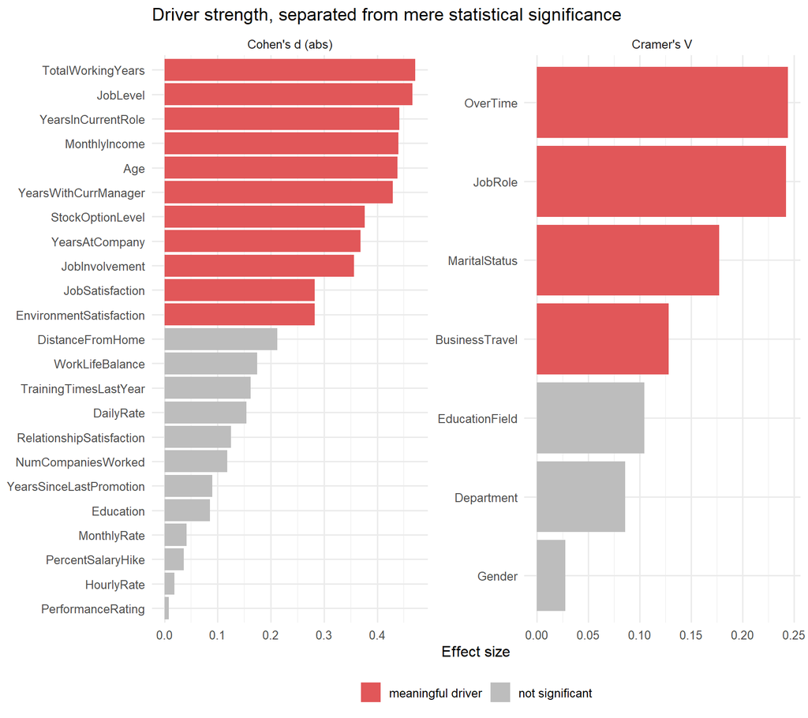

```r
ggplot(results, aes(x = reorder(driver, effect_size), y = effect_size,
                    fill = verdict)) +
  geom_col() +
  coord_flip() +
  facet_wrap(~effect_metric, scales = "free") +
  scale_fill_manual(values = c("meaningful driver" = "#e15759",
                               "significant but trivial" = "#f1a340",
                               "not significant" = "#bdbdbd")) +
  labs(title = "Driver strength, separated from mere statistical significance",
       x = NULL, y = "Effect size", fill = NULL) +
  theme(legend.position = "bottom")
```

## Reading the results honestly

```r
results %>% count(verdict)
```

```
## # A tibble: 2 × 2
##   verdict               n
##   <chr>             <int>
## 1 meaningful driver    15
## 2 not significant      15
```

One honesty note on counting: many of the meaningful numeric drivers are the *same signal wearing different clothes* — `TotalWorkingYears`, `JobLevel`, `MonthlyIncome`, `Age`, `YearsInCurrentRole`, and the rest of the tenure/seniority family are heavily inter-correlated (Phase 1’s correlation plot). Downstream, the memo therefore reports **driver themes** (early tenure, low pay/seniority, overtime, the sales-rep role) rather than pretending each correlated variable is an independent finding. The `direction` column ties each test back to the plain-English claim it supports.

**Not significant** after correction means we can’t distinguish the observed gap from noise at this sample size — not that the effect is proven absent.

## What goes into the models (Phase 3)

All variables go into the models regardless of these verdicts — regularized/multivariate methods can use weak signals and handle correlated features. But when we *interpret* model output for the memo, only the meaningful-driver tier gets translated into recommended actions, and this table is the cross-check that keeps the narrative honest.